# Predict_413_Discussion_Week_4

Singh, Gurjeet

February 2, 2018

## 1. Introduction

For this week’s discussion, we build an Auto Arima model as well as ETS model and test the performance of each model. We again run these two models on training and test dataset.

## 2. Data

For this week’s discussion, I am using the same dataset (U.S Air Carrier Traffic Statistics – Revenue Passenger Miles) from the last week. The figure below shows that this data has strong seasonality within each year. Along with the seasonality, there is also an upward trend to it. We notice that every summer there’s high traffic i.e. peak times. During the months of January and February, we see a dip in the traffic. This makes sense because a lot of people are back to their normal routine after the holidays. Therefore, not many people are travel in those months.

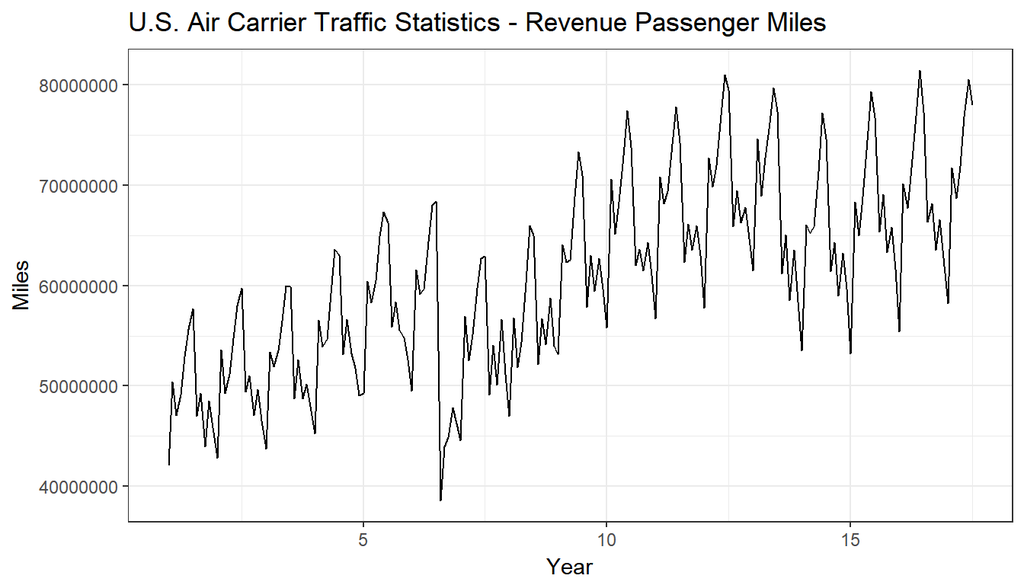

```r
#Import the data
US.air.traffic  <- read.csv("us-air-carrier-traffic-statistic.csv")
colnames(US.air.traffic) <- c("YearMonth", "Revenue_Miles")
autoplot(ts(US.air.traffic[,"Revenue_Miles"],
              frequency = 12)) +
  ggtitle(paste0("U.S. Air ",
                   "Carrier Traffic Statistics ",
                   "- Revenue Passenger Miles")) +
  xlab("Year")+
  ylab("Miles")+
  theme_bw()
```

### 2.1 Split Data - Training/Test set

We split the data into the training set and test set. As per the requirement, we will hold out only 6 months of data for the test.

```r
# #Split the data into training set and test set
data.ts<-ts(US.air.traffic[,"Revenue_Miles"], frequency=12)
train.ts<-ts(US.air.traffic[1:193,"Revenue_Miles"],end=c(2012,2),frequency=12)
test.ts<-ts(US.air.traffic[194:199,"Revenue_Miles"],start=c(2012,3),frequency=12)
```

## 3. Model

### 3.1 Auto Models - Arima & ETS Full Data

```r
#Auto Arima
traffic.arima <- auto.arima(data.ts)
ta.model.mets <- cbind("AIC" = traffic.arima$aic, "AICc"=traffic.arima$aicc,
                       "BIC" =traffic.arima$bic)
#ETS AUTO Model
traffic.ets <- ets(data.ts)
te.model.mets <- cbind("AIC" = traffic.ets$aic, "AICc"=traffic.ets$aicc,
                       "BIC" =traffic.ets$bic)
aa.model <- accuracy(traffic.arima)
est.model <- accuracy(traffic.ets)

rownames(ta.model.mets) <- "Auto Arima"
rownames(te.model.mets) <- "Auto ETS"
rownames(aa.model) <- "Auto Arima Model"
rownames(est.model) <- "Auto EST Model"

knitr::kable(rbind(ta.model.mets, te.model.mets),
             caption = "AIC, AICc, BIC for Arima and ETS Models")
```

AIC, AICc, BIC for Arima and ETS Models

|  | AIC | AICc | BIC |
| --- | --- | --- | --- |
| Auto Arima | 5968.417 | 5968.749 | 5984.573 |
| Auto ETS | 6833.503 | 6836.126 | 6882.902 |

```r
knitr::kable(rbind(aa.model, est.model),
             caption = "Metrics for each model using full data")
```

Metrics for each model using full data

|  | ME | RMSE | MAE | MPE | MAPE | MASE | ACF1 |
| --- | --- | --- | --- | --- | --- | --- | --- |
| Auto Arima Model | 17726.37 | 1895929 | 1139228 | -0.0876403 | 1.997818 | 0.3670247 | -0.0024269 |
| Auto EST Model | 123403.47 | 1881491 | 1256336 | 0.1346370 | 2.231370 | 0.4047536 | 0.0182516 |

### 3.2 Auto Model - Train & Test Data

We create the Auto Arima and ETS models using the training dataset. The first table shows the AIC, AICc, and BIC values of each model. Again, we notice that auto Arima performed better than auto ETS model.

The second table also shows that auto Arima outperformed the ETS model in the test set.

```r
#Auto Arima using training dataset
traffic.arima.train <- auto.arima(train.ts)
fcast.arima.train <- forecast(traffic.arima.train, h=6)
acc.arima <- accuracy(fcast.arima.train, test.ts)
rownames(acc.arima) <- c("Auto Arima - Train","Auto Arima - Test")
#Auto ETS using training dataset
traffic.ets.train <- ets(train.ts)
fcast.ets.train <- forecast(traffic.ets.train, h=6)
acc.ets <- accuracy(fcast.ets.train, test.ts)
rownames(acc.ets) <- c("Auto ETS - Train","Auto ETS - Test")
ta.train.mets <- cbind("AIC"=traffic.arima.train$aic, "AICc"=traffic.arima.train$aicc,
                       "BIC"=traffic.arima.train$bic)
te.train.mets <- cbind("AIC"=traffic.ets.train$aic, "AICc"=traffic.ets.train$aicc,
                       "BIC"=traffic.ets.train$bic)
rownames(ta.train.mets) <- "Auto Arima - Train"
rownames(te.train.mets) <- "Auto ETS - Train"
knitr::kable(rbind(ta.train.mets, te.train.mets),
             caption = "AIC, AICc, BIC for Arima and ETS Models")
```

AIC, AICc, BIC for Arima and ETS Models

|  | AIC | AICc | BIC |
| --- | --- | --- | --- |
| Auto Arima - Train | 5782.996 | 5783.339 | 5798.988 |
| Auto ETS - Train | 6627.111 | 6629.823 | 6676.052 |

```r
knitr::kable(rbind(acc.arima[,1:7], acc.ets[,1:7]),
             caption = "Metrics for each model")
```

Metrics for each model

|  | ME | RMSE | MAE | MPE | MAPE | MASE | ACF1 |
| --- | --- | --- | --- | --- | --- | --- | --- |
| Auto Arima - Train | 16700.78 | 1923840 | 1161344.6 | -0.0964374 | 2.043157 | 0.3653068 | -0.0019718 |
| Auto Arima - Test | -887716.19 | 1026463 | 887716.2 | -1.1647129 | 1.164713 | 0.2792356 | 0.3591187 |
| Auto ETS - Train | 115236.10 | 1904285 | 1273352.1 | 0.1193085 | 2.269276 | 0.4005394 | 0.0192389 |
| Auto ETS - Test | 1912761.30 | 2031558 | 1912761.3 | 2.5449616 | 2.544962 | 0.6016688 | 0.3539079 |

## 4. Conclusion

R Code available on my GitHub page (https://github.com/Singh-Gurjeet) in the Time Series and Forecasting repository.